# HPSNZ Environmental Report 2020

Ben Day

20/08/2020

## Introduction

This R Markdown document allows the combination of analysis and explanation for future reference and reproducibility. Since the inaugural HPSNZ Environmental Report ahead of the Rio 2016 Games, the depth and detail of the reported measures have been enhanced for the Tokyo 2020 Games and this will enable better preparation.

Precisely that this environmental report for performance preparation is refined during each cycle is the reason to document the analytical processes well. This enable continuous evaluation and improvement with as little friction as possible between personal analysis styles and data management.

## Date periods

Weather station measurement data was collected for two extended periods to account for lead-in athlete training preparation at the venue. Therefore the periods in focus for the 2020 Tokyo Games were:

1. Olympic period, *10 July - 9 August*
2. Paralympic period, *11 August - 6 September*

These dates include two weeks prior to each official Games period (24 July - 9 August and 25 August - 6 September, respectfully)

Data from years 2015 to present year 2020 will be gathered for analysis.

## Venues

Competition venues for Olympic and Paralympic sports are detailed below. Weather station measurement data was collected for all venues for both periods (1) and (2).

Weather stations were selected as closest proximity to official competition venues.

## Data sources

For the Tokyo 2020 competition venues a combination of in-person measurements and publicly available weather station data was analysed and presented. Julia Casadio and Kim Simperingham were involved with the collection of water quality and air quality measurements alongside Japanese local experts, and Ben Day was responsible for the collection and analysis of weather station measurement data. The latter is the focus of this report.

The Japanese Meteorlogical Agency [www.data.jma.go.jp/risk/obsdl/index.php] provides weather station measurements from around the country as hourly observations in various metrics. By selecting appropriate weather stations on a map, and defining an appropriate date range as detailed below, the following measurements can be downloaded as csv:

- Temperature (deg C)
- Rainfall (mm in previous hour)
- Relative humidity (%)
- Wind speed (m/s)

### Weather station measurement data

One .csv file was downloaded for each venue for each period, giving 9 x 2 files of data for each year. Then all files were collated into a ‘master’ dataset for analysis. The R code used to do this is detailed below.

```r
# Check working diretory
list.files(path = 'data/2020 update')
```

```
## [1] "Olympic_10Jul-9Aug"    "Paralympic_11Aug-6Sep"
```

```r
folders_periods <- list.files(path = 'data/2020 update')

# List files in each folder and get filenames
list.files(path = paste('data/2020 update', folders_periods[1], '2020', sep = "/"))
```

```
## [1] "edogawa.csv"    "fuchu.csv"      "izu.csv"        "mobara.csv"
## [5] "nerima.csv"     "sapporo.csv"    "tokorozawa.csv" "tokyo.csv"
## [9] "tsujido.csv"
```

```r
files_o <- list.files(path = paste('data/2020 update', folders_periods[1], '2020', sep = "/"),
                      pattern = "*.csv")
files_p <- list.files(path = paste('data/2020 update', folders_periods[2], '2020', sep = "/"),
                      pattern = "*.csv")
```

A preview of one file is shown below.

```r
# Preview top 10 lines
head(read.csv(file = './data/2020 update/Olympic_10Jul-9Aug/2020/edogawa.csv',
              header = FALSE, skip = 2), n = 10)
```

[output not shown]

[output cut: 18 more lines]

Individual data files can be collated and wrangled as follows:

1. Skip header rows
2. Identify useful columns of data
3. Rename these columns for our use

```r
a2020 <- lapply(files_o, function(i) {

  # Some venues have alternate column structure
  if (i %in% c("izu.csv", "sapporo.csv", "tokyo.csv")) {
    useful_cols <- c(1, 2, 5, 9, 14) }
  else {
    useful_cols <- c(1, 2, 5, 8, 13)
  }

  read.csv(file = paste0('./data/2020 update/', folders_periods[1], '/2020/', i),
           header = FALSE, skip = 1) %>%
    mutate_all(as.character) %>%
    slice(5:nrow(.)) %>%
    select(useful_cols) %>%
    setNames(nm = c('datetime', 'temperature', 'rainfall', 'wind speed','humidity'))

  })

a2020 <- bind_rows(a2020, .id = "venue")
a2020$venue <- lapply(a2020$venue, function(j) { j <- gsub('.csv', '', files_o[as.numeric(j)])})
```

This collates 1 year of venue weather observations into a file of the following form.

```r
head(a2020, n = 10)
```

```
##      venue           datetime temperature rainfall wind speed humidity
## 1  edogawa  2020/7/10 1:00:00        23.1      0.0        6.4
## 2  edogawa  2020/7/10 2:00:00        23.1      0.0        5.1
## 3  edogawa  2020/7/10 3:00:00        23.2      0.0        5.3
## 4  edogawa  2020/7/10 4:00:00        23.1      0.0        3.5
## 5  edogawa  2020/7/10 5:00:00        23.1      0.0        3.3
## 6  edogawa  2020/7/10 6:00:00        22.9      0.5        5.5
## 7  edogawa  2020/7/10 7:00:00        23.2      0.0        5.7
## 8  edogawa  2020/7/10 8:00:00        23.3      0.0        4.7
## 9  edogawa  2020/7/10 9:00:00        23.9      0.0        6.1
## 10 edogawa 2020/7/10 10:00:00        24.2      0.0        5.2
```

Using a year vector it is possible to iterately collate venue data files, and finally bring together into a single master dataset.

```r
# Years vector
years <- c("2015", "2016", "2017", "2018", "2019", "2020")

for (j in 1:length(years)) {

  # Get filenames
  filenames = list.files(path = paste0('./data/2020 update/Olympic_10Jul-9Aug/',
                                       years[j]), pattern = "*.csv")

  # dataframe
  df <- data.frame(matrix(nrow = 0, ncol = 5))

  df <- lapply(filenames, function(i) {

    # Some venues have alternate column structure
    if (i %in% c("izu.csv", "sapporo.csv", "tokyo.csv")) {
        useful_cols <- c(1, 2, 5, 9, 14) }
    else {
        useful_cols <- c(1, 2, 5, 8, 13) }

    read.csv(file = paste0('./data/2020 update/Olympic_10Jul-9Aug/',
                                           years[j], '/', i), header = FALSE, skip = 1) %>%
    mutate_all(as.character) %>%
    slice(5:nrow(.)) %>%
    select(useful_cols) %>%
    setNames(nm = c('datetime', 'temperature', 'rainfall', 'wind speed','humidity')) %>%
    mutate(venue = gsub('.csv', '', i))
  }) %>%
  bind_rows()

  # Then combine into year dataframe
  ifelse(
    exists('oly_df'),
    oly_df <- rbind(oly_df, df),
    oly_df <- df
  )
}

# End of years
tail(oly_df)
```

```
##                 datetime temperature rainfall wind speed humidity   venue
## 40171  2020/8/9 19:00:00        28.8      0.0        1.2          tsujido
## 40172  2020/8/9 20:00:00        28.6      0.0        3.1          tsujido
## 40173  2020/8/9 21:00:00        28.9      0.0        2.8          tsujido
## 40174  2020/8/9 22:00:00        28.5      0.0        4.2          tsujido
## 40175  2020/8/9 23:00:00        28.3      0.0        1.5          tsujido
## 40176 2020/8/10 00:00:00        28.0      0.0        1.1          tsujido
```

The same method can be used to collate Paralympic period data.

### Quality assurance

A quick calculation of approximately how many hourly observations we are expecting to have in our ‘master’ dataset can be done as follows.

24 hours per day * 31 days in period * 6 years * 9 venues = ~40,000 rows of measurements

Passing this check, we can also check the distribution of measurements across venues and across years.

```r
# Olympic
nrow(oly_df)
```

```
## [1] 40176
```

```r
oly_df %>% group_by(venue) %>% summarise(count = n())
```

```
## # A tibble: 9 x 2
##   venue      count
##   <chr>      <int>
## 1 edogawa     4464
## 2 fuchu       4464
## 3 izu         4464
## 4 mobara      4464
## 5 nerima      4464
## 6 sapporo     4464
## 7 tokorozawa  4464
## 8 tokyo       4464
## 9 tsujido     4464
```

```r
oly_df %>% group_by(year(datetime)) %>% summarise(count = n())
```

```
## # A tibble: 6 x 2
##   `year(datetime)` count
##              <dbl> <int>
## 1             2015  6696
## 2             2016  6696
## 3             2017  6696
## 4             2018  6696
## 5             2019  6696
## 6             2020  6696
```

```r
# Paralympic
nrow(para_df)
```

```
## [1] 34992
```

```r
para_df %>% group_by(venue) %>% summarise(count = n())
```

```
## # A tibble: 9 x 2
##   venue      count
##   <chr>      <int>
## 1 edogawa     3888
## 2 fuchu       3888
## 3 izu         3888
## 4 mobara      3888
## 5 nerima      3888
## 6 sapporo     3888
## 7 tokorozawa  3888
## 8 tokyo       3888
## 9 tsujido     3888
```

```r
para_df %>% group_by(year(datetime)) %>% summarise(count = n())
```

```
## # A tibble: 6 x 2
##   `year(datetime)` count
##              <dbl> <int>
## 1             2015  5832
## 2             2016  5832
## 3             2017  5832
## 4             2018  5832
## 5             2019  5832
## 6             2020  5832
```

## Statistical analysis

Using the `tidyverse` and `lubridate` R packages these summaries are straightforward. These can be done by aggregating the hourly measurements over time periods and for each venue.

#### Prepare dataset

```r
oly_df <- oly_df %>%
  mutate_at(.vars = vars(temperature, rainfall, `wind speed`, humidity), as.numeric) %>%
  mutate(venue = as.factor(venue),
         datetime = as_datetime(datetime),
         period = ifelse(month(datetime) == 7 & day(datetime) < 24, "lead-in", "games")) # define period

para_df <- para_df %>%
  mutate_at(.vars = vars(temperature, rainfall, `wind speed`, humidity), as.numeric) %>%
  mutate(venue = as.factor(venue),
         datetime = as_datetime(datetime),
         period = ifelse(month(datetime) == 8 & day(datetime) < 25, "lead-in", "games")) # define period)
```

#### Maximum day time temperature

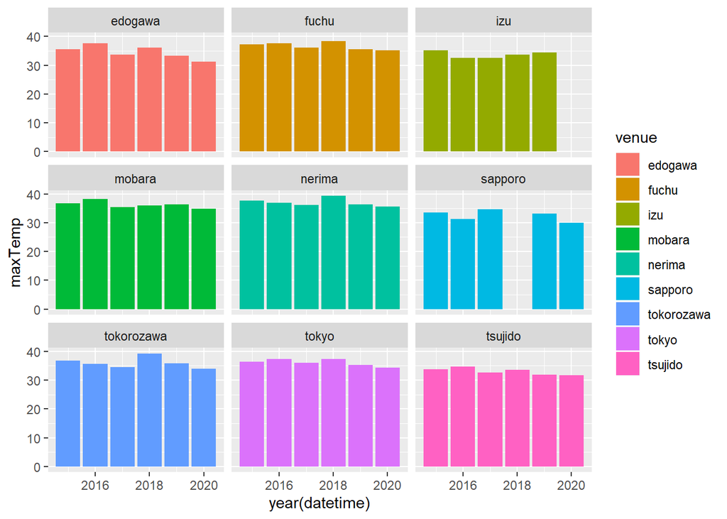

```r
# Maximum day time temp
q1 <- oly_df %>%
  group_by(year(datetime), venue) %>%
  summarise(maxTemp = max(temperature))
ggplot(q1) +
  geom_bar(aes(x = `year(datetime)`, y = maxTemp, fill = venue), stat = 'identity') +
  facet_wrap(vars(venue))
```

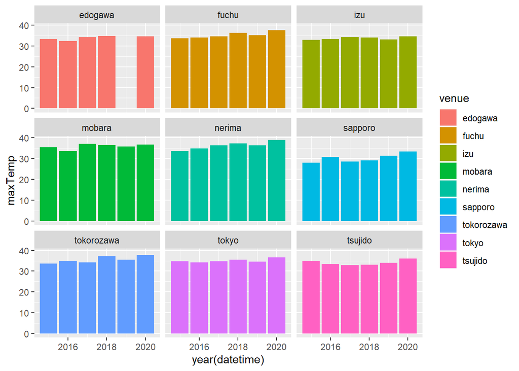

```r
p1 <- para_df %>%
  group_by(year(datetime), venue) %>%
  summarise(maxTemp = max(temperature))
ggplot(p1) +
  geom_bar(aes(x = `year(datetime)`, y = maxTemp, fill = venue), stat = 'identity') +
  facet_wrap(vars(venue))
```

#### Humidity at max day time temperature

```r
# Humidity at hottest part of day
q1q2 <- oly_df %>%
  filter(hour(datetime) >= 5 & hour(datetime) <= 19) %>%
  group_by(year(datetime), venue) %>%
  mutate(maxTemp = max(temperature)) %>%
  filter(temperature == maxTemp) %>%
  select(venue, maxTemp, humidity) %>%
  unique()
p1p2 <- para_df %>%
  filter(hour(datetime) >= 5 & hour(datetime) <= 19) %>%
  group_by(year(datetime), venue) %>%
  mutate(maxTemp = max(temperature)) %>%
  filter(temperature == maxTemp) %>%
  select(venue, maxTemp, humidity) %>%
  unique()
```

#### ‘Feels like’ temperature

The calculation of ‘feels like’ temperature (also known as *apparent temperature*) uses the following formula with dry-bulb temperature and relative humidity factors. This is considered accurate for temperatures equal to or greater than 27 degrees Celsius and for humidity equal to or greater than 40%.

`heatIndex = c1 + c2*T + c3*R + c4*T*R + c5*T^2 + c6*R^2 + c7*T^2*R + c8*T*R^2 + c9*T^2*R^2`

Where

`T` = ambient dry-bulb temperature (deg C) `R` = relative humidity (%) `c1` = -8.78469475556 `c2` = 1.61139411 `c3` = 2.33854883889 `c4` = -0.14611605 `c5` = -0.012308094 `c6` = -0.0164248277778 `c7` = 0.002211732 `c8` = 0.00072546 `c9` = -0.000003582

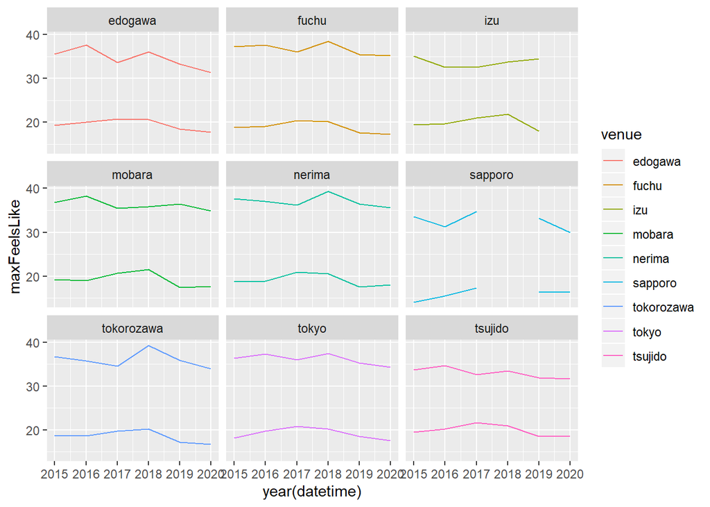

```r
# Feels like maximum temperature
q3q4 <- oly_df %>%
  filter(hour(datetime) >= 5 & hour(datetime) <= 19) %>%
  mutate(feelsLike = heatIndex(temperature, humidity)) %>%
  select(-rainfall, -`wind speed`) %>%
  group_by(year(datetime), venue) %>%
  summarise(maxFeelsLike = max(feelsLike),
            minFeelsLike = min(feelsLike))
ggplot(q3q4) +
  geom_line(aes(x = `year(datetime)`, y = maxFeelsLike, color = venue)) +
  geom_line(aes(x = `year(datetime)`, y = minFeelsLike, color = venue)) +
  facet_wrap(vars(venue))
```

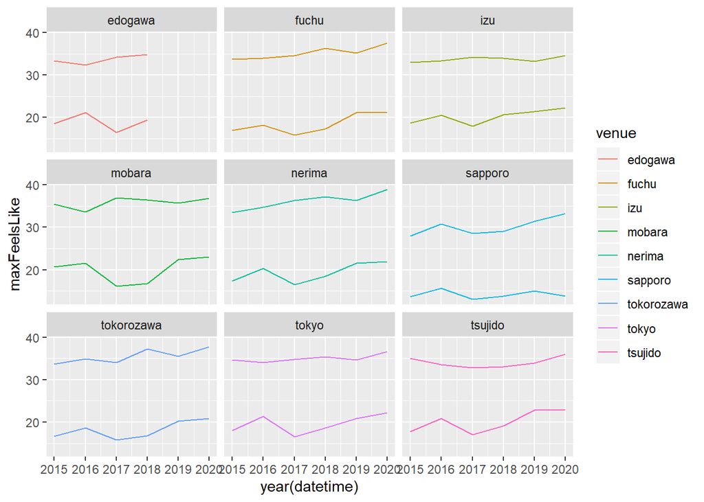

```r
p3p4 <- para_df %>%
  filter(hour(datetime) >= 5 & hour(datetime) <= 19) %>%
  mutate(feelsLike = heatIndex(temperature, humidity)) %>%
  select(-rainfall, -`wind speed`) %>%
  group_by(year(datetime), venue) %>%
  summarise(maxFeelsLike = max(feelsLike),
            minFeelsLike = min(feelsLike))
ggplot(p3p4) +
  geom_line(aes(x = `year(datetime)`, y = maxFeelsLike, color = venue)) +
  geom_line(aes(x = `year(datetime)`, y = minFeelsLike, color = venue)) +
  facet_wrap(vars(venue))
```

#### Days above 30, 35, 40 deg C

It is useful to compare venues by how many days where the ‘feels like’ temperature exceeded certain thresholds.

```r
q5q6q7 <- oly_df %>%
  mutate(feelsLike = heatIndex(temperature, humidity)) %>%
  group_by(year(datetime), day(datetime), venue) %>%
  summarise(maxFeelsLike = max(feelsLike)) %>%
  group_by(venue, `year(datetime)`) %>%
  mutate(over30 = round((n_distinct(`day(datetime)`[maxFeelsLike >= 30])/
                           n_distinct(`day(datetime)`))*100, 0),
         over35 = round((n_distinct(`day(datetime)`[maxFeelsLike >= 35])/
                           n_distinct(`day(datetime)`))*100, 0),
         over40 = round((n_distinct(`day(datetime)`[maxFeelsLike >= 40])/
                           n_distinct(`day(datetime)`))*100, 0)) %>%
  select(`year(datetime)`, venue, over30, over35, over40) %>%
  unique() %>%
  arrange(venue)
p5p6p7 <- para_df %>%
  mutate(feelsLike = heatIndex(temperature, humidity)) %>%
  group_by(year(datetime), day(datetime), venue) %>%
  summarise(maxFeelsLike = max(feelsLike)) %>%
  group_by(venue, `year(datetime)`) %>%
  mutate(over30 = round((n_distinct(`day(datetime)`[maxFeelsLike >= 30])/
                           n_distinct(`day(datetime)`))*100, 0),
         over35 = round((n_distinct(`day(datetime)`[maxFeelsLike >= 35])/
                           n_distinct(`day(datetime)`))*100, 0),
         over40 = round((n_distinct(`day(datetime)`[maxFeelsLike >= 40])/
                           n_distinct(`day(datetime)`))*100, 0)) %>%
  select(`year(datetime)`, venue, over30, over35, over40) %>%
  unique() %>%
  arrange(venue)
```

#### Total rainfall over period

```r
# Total rainfall
q8 <- oly_df %>%
  group_by(year(datetime), venue) %>%
  summarise(rain = sum(rainfall))

p8 <- para_df %>%
  group_by(year(datetime), venue) %>%
  summarise(rain = sum(rainfall))
```

#### Percentage of days rained

```r
# Number days rained
q9 <- oly_df %>%
  group_by(year(datetime), day(datetime), venue) %>%
  summarise(rain = sum(rainfall)) %>%
  group_by(venue, `year(datetime)`) %>%
  mutate(daysrained = round(n_distinct(`day(datetime)`[rain > 0])/
                              n_distinct(`day(datetime)`)*100, 0)) %>%
  select(`year(datetime)`, venue, daysrained) %>%
  unique()

p9 <- para_df %>%
  group_by(year(datetime), day(datetime), venue) %>%
  summarise(rain = sum(rainfall)) %>%
  group_by(venue, `year(datetime)`) %>%
  mutate(daysrained = round(n_distinct(`day(datetime)`[rain > 0])/
                              n_distinct(`day(datetime)`)*100, 0)) %>%
  select(`year(datetime)`, venue, daysrained) %>%
  unique()
```

### Summary table

Bringing together the analysis pieces for each aspect listed above we are left with the following.

```r
allo <- left_join(q1q2, q3q4) %>%
  left_join(., q5q6q7) %>%
  left_join(., q8) %>%
  left_join(., q9) %>%
  rename('Year' = `year(datetime)`,
         'Venue' = venue,
         'Max Temp' = maxTemp,
         'Humidity (%)' = humidity,
         'Max Feels Like' = maxFeelsLike,
         'Min Feels Like' = minFeelsLike,
         'Days over 30 (%)' = over30,
         'Days over 35 (%)' = over35,
         'Days over 40 (%)' = over40,
         'Total Rainfall (mm)' = rain,
         'Days rained (%)' = daysrained) %>%
  filter(Year != 2015)
knitr::kable(allo)
```

| Year | Venue | Max Temp | Humidity (%) | Max Feels Like | Min Feels Like | Days over 30 (%) | Days over 35 (%) | Days over 40 (%) | Total Rainfall (mm) | Days rained (%) |
| --- | --- | --- | --- | --- | --- | --- | --- | --- | --- | --- |
| 2016 | edogawa | 37.6 | NA | 37.6 | 20.0 | 52 | 3 | 0 | 108.0 | 39 |
| 2016 | fuchu | 37.6 | NA | 37.6 | 19.1 | 58 | 3 | 0 | 119.5 | 32 |
| 2016 | izu | 32.5 | 62 | 32.5 | 19.7 | 32 | 0 | 0 | 118.0 | 26 |
| 2016 | mobara | 38.2 | NA | 38.2 | 19.0 | 45 | 3 | 0 | 68.0 | 39 |
| 2016 | nerima | 37.0 | NA | 37.0 | 18.9 | 58 | 3 | 0 | 134.5 | 32 |
| 2016 | sapporo | 31.3 | 46 | 31.3 | 15.5 | 6 | 0 | 0 | 120.5 | 26 |
| 2016 | tokorozawa | 35.7 | NA | 35.7 | 18.7 | 55 | 3 | 0 | 96.0 | 29 |
| 2016 | tokyo | 37.3 | 38 | 37.3 | 19.8 | 55 | 3 | 0 | 112.5 | 35 |
| 2016 | tsujido | 34.7 | NA | 34.7 | 20.2 | 35 | 0 | 0 | 101.5 | 29 |
| 2017 | edogawa | 33.6 | NA | 33.6 | 20.8 | 55 | 0 | 0 | 59.0 | 29 |
| 2017 | fuchu | 36.1 | NA | 36.1 | 20.4 | 77 | 3 | 0 | 121.0 | 29 |
| 2017 | izu | 32.6 | 65 | 32.6 | 21.0 | 45 | 0 | 0 | 67.5 | 23 |
| 2017 | mobara | 35.5 | NA | 35.5 | 20.7 | 74 | 3 | 0 | 60.5 | 26 |
| 2017 | nerima | 36.2 | NA | 36.2 | 20.9 | 77 | 10 | 0 | 95.5 | 35 |
| 2017 | sapporo | 34.7 | 38 | 34.7 | 17.3 | 13 | 0 | 0 | 75.0 | 35 |
| 2017 | tokorozawa | 34.6 | NA | 34.6 | 19.8 | 68 | 0 | 0 | 135.5 | 29 |
| 2017 | tokyo | 36.0 | 50 | 36.0 | 20.8 | 77 | 3 | 0 | 79.0 | 29 |
| 2017 | tsujido | 32.6 | NA | 32.6 | 21.7 | 32 | 0 | 0 | 137.5 | 26 |
| 2018 | edogawa | 36.1 | NA | 36.1 | 20.6 | 77 | 6 | 0 | 66.5 | 19 |
| 2018 | fuchu | 38.4 | NA | 38.4 | 20.1 | 81 | 23 | 0 | 156.5 | 26 |
| 2018 | izu | 33.7 | 57 | 33.7 | 21.9 | 71 | 0 | 0 | 77.5 | 23 |
| 2018 | izu | 33.7 | 64 | 33.7 | 21.9 | 71 | 0 | 0 | 77.5 | 23 |
| 2018 | mobara | 35.9 | NA | 35.9 | 21.5 | 81 | 16 | 0 | 65.5 | 16 |
| 2018 | nerima | 39.3 | NA | 39.3 | 20.5 | 81 | 52 | 0 | 139.0 | 26 |
| 2018 | tokorozawa | 39.2 | NA | 39.2 | 20.2 | 84 | 35 | 0 | 145.0 | 26 |
| 2018 | tokyo | 37.4 | 38 | 37.4 | 20.2 | 81 | 10 | 0 | 122.5 | 23 |
| 2018 | tsujido | 33.5 | NA | 33.5 | 20.9 | 77 | 0 | 0 | 106.5 | 26 |
| 2019 | edogawa | 33.3 | NA | 33.3 | 18.5 | 52 | 0 | 0 | 121.5 | 39 |
| 2019 | fuchu | 35.5 | NA | 35.5 | 17.6 | 55 | 16 | 0 | 114.5 | 45 |
| 2019 | izu | 34.5 | 54 | 34.5 | 18.0 | 45 | 0 | 0 | 146.0 | 42 |
| 2019 | mobara | 36.4 | NA | 36.4 | 17.4 | 55 | 19 | 0 | 104.0 | 35 |
| 2019 | nerima | 36.4 | NA | 36.4 | 17.6 | 58 | 26 | 0 | 126.5 | 39 |
| 2019 | sapporo | 33.2 | 56 | 33.2 | 16.5 | 29 | 0 | 0 | 71.5 | 39 |
| 2019 | sapporo | 33.2 | 59 | 33.2 | 16.5 | 29 | 0 | 0 | 71.5 | 39 |
| 2019 | tokorozawa | 35.9 | NA | 35.9 | 17.2 | 58 | 13 | 0 | 157.0 | 42 |
| 2019 | tokyo | 35.3 | 61 | 35.3 | 18.6 | 58 | 3 | 0 | 138.0 | 48 |
| 2019 | tsujido | 31.9 | NA | 31.9 | 18.5 | 48 | 0 | 0 | 91.5 | 45 |
| 2020 | edogawa | 31.3 | NA | 31.3 | 17.7 | 29 | 0 | 0 | 122.5 | 55 |
| 2020 | fuchu | 35.2 | NA | 35.2 | 17.3 | 42 | 3 | 0 | 178.0 | 65 |
| 2020 | mobara | 34.9 | NA | 34.9 | 17.7 | 48 | 0 | 0 | 146.5 | 55 |
| 2020 | nerima | 35.6 | NA | 35.6 | 18.0 | 48 | 6 | 0 | 168.5 | 61 |
| 2020 | sapporo | 30.0 | 58 | 30.0 | 16.4 | 3 | 0 | 0 | 25.0 | 23 |
| 2020 | tokorozawa | 34.0 | NA | 34.0 | 16.8 | 39 | 0 | 0 | 239.5 | 71 |
| 2020 | tokyo | 34.3 | 51 | 34.3 | 17.6 | 42 | 0 | 0 | 156.5 | 55 |
| 2020 | tsujido | 31.7 | NA | 31.7 | 18.5 | 32 | 0 | 0 | 175.0 | 58 |

```r
allp <- left_join(p1p2, p3p4) %>%
  left_join(., p5p6p7) %>%
  left_join(., p8) %>%
  left_join(., p9) %>%
  rename('Year' = `year(datetime)`,
         'Venue' = venue,
         'Max Temp' = maxTemp,
         'Humidity (%)' = humidity,
         'Max Feels Like' = maxFeelsLike,
         'Min Feels Like' = minFeelsLike,
         'Days over 30 (%)' = over30,
         'Days over 35 (%)' = over35,
         'Days over 40 (%)' = over40,
         'Total Rainfall (mm)' = rain,
         'Days rained (%)' = daysrained) %>%
  filter(Year != 2015)
knitr::kable(allp)
```

| Year | Venue | Max Temp | Humidity (%) | Max Feels Like | Min Feels Like | Days over 30 (%) | Days over 35 (%) | Days over 40 (%) | Total Rainfall (mm) | Days rained (%) |
| --- | --- | --- | --- | --- | --- | --- | --- | --- | --- | --- |
| 2016 | edogawa | 32.4 | NA | 32.4 | 21.1 | 61 | 0 | 0 | 174.5 | 32 |
| 2016 | fuchu | 34.0 | NA | 34.0 | 18.2 | 61 | 0 | 0 | 385.5 | 50 |
| 2016 | izu | 33.3 | 57 | 33.3 | 20.5 | 18 | 0 | 0 | 237.0 | 43 |
| 2016 | mobara | 33.6 | NA | 33.6 | 21.5 | 57 | 0 | 0 | 322.5 | 46 |
| 2016 | nerima | 34.8 | NA | 34.8 | 20.3 | 75 | 0 | 0 | 383.5 | 50 |
| 2016 | sapporo | 30.8 | 50 | 30.8 | 15.6 | 11 | 0 | 0 | 265.5 | 39 |
| 2016 | tokorozawa | 34.9 | NA | 34.9 | 18.7 | 54 | 0 | 0 | 459.5 | 50 |
| 2016 | tokyo | 34.1 | 59 | 34.1 | 21.4 | 57 | 0 | 0 | 372.0 | 46 |
| 2016 | tsujido | 33.5 | NA | 33.5 | 20.9 | 54 | 0 | 0 | 188.0 | 39 |
| 2017 | edogawa | 34.2 | NA | 34.2 | 16.5 | 32 | 0 | 0 | 89.0 | 50 |
| 2017 | fuchu | 34.6 | NA | 34.6 | 15.8 | 39 | 0 | 0 | 117.5 | 46 |
| 2017 | izu | 34.2 | 59 | 34.2 | 17.9 | 25 | 0 | 0 | 86.0 | 36 |
| 2017 | mobara | 37.0 | NA | 37.0 | 16.1 | 43 | 7 | 0 | 104.0 | 54 |
| 2017 | nerima | 36.4 | NA | 36.4 | 16.5 | 39 | 4 | 0 | 214.5 | 50 |
| 2017 | sapporo | 28.6 | 33 | 28.6 | 13.1 | 0 | 0 | 0 | 74.0 | 21 |
| 2017 | tokorozawa | 34.1 | NA | 34.1 | 15.8 | 36 | 0 | 0 | 207.0 | 54 |
| 2017 | tokyo | 34.8 | 52 | 34.8 | 16.6 | 36 | 0 | 0 | 164.5 | 54 |
| 2017 | tsujido | 32.8 | NA | 32.8 | 17.0 | 39 | 0 | 0 | 88.5 | 43 |
| 2018 | edogawa | 34.8 | NA | 34.8 | 19.4 | 50 | 0 | 0 | 34.0 | 25 |
| 2018 | fuchu | 36.3 | NA | 36.3 | 17.3 | 57 | 14 | 0 | 153.5 | 50 |
| 2018 | izu | 34.0 | 58 | 34.0 | 20.7 | 50 | 0 | 0 | 213.5 | 43 |
| 2018 | mobara | 36.5 | NA | 36.5 | 16.8 | 75 | 11 | 0 | 52.5 | 36 |
| 2018 | nerima | 37.2 | NA | 37.2 | 18.5 | 64 | 18 | 0 | 203.0 | 46 |
| 2018 | sapporo | 29.1 | 70 | 29.1 | 13.8 | 0 | 0 | 0 | 249.5 | 64 |
| 2018 | sapporo | 29.1 | 71 | 29.1 | 13.8 | 0 | 0 | 0 | 249.5 | 64 |
| 2018 | tokorozawa | 37.2 | NA | 37.2 | 16.8 | 50 | 11 | 0 | 188.0 | 46 |
| 2018 | tokyo | 35.4 | 58 | 35.4 | 18.7 | 64 | 11 | 0 | 77.5 | 43 |
| 2018 | tokyo | 35.4 | 55 | 35.4 | 18.7 | 64 | 11 | 0 | 77.5 | 43 |
| 2018 | tsujido | 33.0 | NA | 33.0 | 19.1 | 54 | 0 | 0 | 87.0 | 32 |
| 2019 | fuchu | 35.2 | NA | 35.2 | 21.2 | 61 | 4 | 0 | 221.5 | 46 |
| 2019 | izu | 33.2 | 53 | 33.2 | 21.4 | 25 | 0 | 0 | 134.5 | 36 |
| 2019 | mobara | 35.7 | NA | 35.7 | 22.4 | 64 | 7 | 0 | 76.5 | 43 |
| 2019 | nerima | 36.3 | NA | 36.3 | 21.5 | 64 | 4 | 0 | 96.0 | 43 |
| 2019 | sapporo | 31.4 | 50 | 31.4 | 15.0 | 4 | 0 | 0 | 99.0 | 39 |
| 2019 | tokorozawa | 35.5 | NA | 35.5 | 20.3 | 57 | 4 | 0 | 178.0 | 61 |
| 2019 | tokyo | 34.6 | 55 | 34.6 | 20.9 | 64 | 0 | 0 | 111.5 | 46 |
| 2019 | tsujido | 33.9 | NA | 33.9 | 22.8 | 61 | 0 | 0 | 108.0 | 25 |
| 2020 | edogawa | 34.6 | NA | 34.6 | 23.3 | 86 | 0 | 0 | 41.0 | 25 |
| 2020 | fuchu | 37.6 | NA | 37.6 | 21.1 | 86 | 25 | 0 | 111.0 | 39 |
| 2020 | izu | 34.6 | 61 | 34.6 | 22.2 | 57 | 0 | 0 | 125.5 | 25 |
| 2020 | mobara | 36.8 | NA | 36.8 | 23.0 | 89 | 39 | 0 | 41.0 | 29 |
| 2020 | nerima | 38.9 | NA | 38.9 | 21.9 | 86 | 32 | 0 | 124.5 | 32 |
| 2020 | sapporo | 33.3 | 53 | 33.3 | 13.8 | 25 | 0 | 0 | 107.0 | 29 |
| 2020 | tokorozawa | 37.8 | NA | 37.8 | 20.8 | 86 | 29 | 0 | 83.0 | 36 |
| 2020 | tokyo | 36.6 | 53 | 36.6 | 22.2 | 86 | 21 | 0 | 107.0 | 29 |
| 2020 | tsujido | 36.0 | NA | 36.0 | 23.0 | 89 | 4 | 0 | 56.0 | 29 |

#### Olympic Period

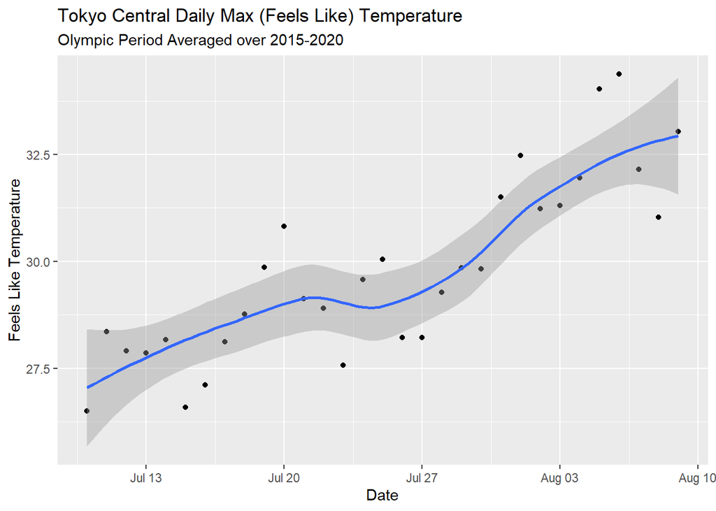

```r
gdf_o <- oly_df %>%
  filter(venue == 'tokyo',
         hour(datetime) != 0) %>%
  mutate(feelsLike = as_vector(map2(temperature, humidity, heatIndex))) %>%
  group_by(day(datetime)) %>%
  summarise(`Feels Like Temperature` = mean(feelsLike, na.rm = TRUE),
            Date = max(date(datetime))) %>%
  rename('Day' = `day(datetime)`) %>%
  filter()

ggplot(data = gdf_o, aes(x = Date, y = `Feels Like Temperature`)) +
  geom_point() +
  geom_smooth(se = TRUE) +
  ggtitle('Tokyo Central Daily Max (Feels Like) Temperature',
          subtitle = 'Olympic Period Averaged over 2015-2020')
```

#### Paralympic Period

Below is the same chart for the Paralympic period.

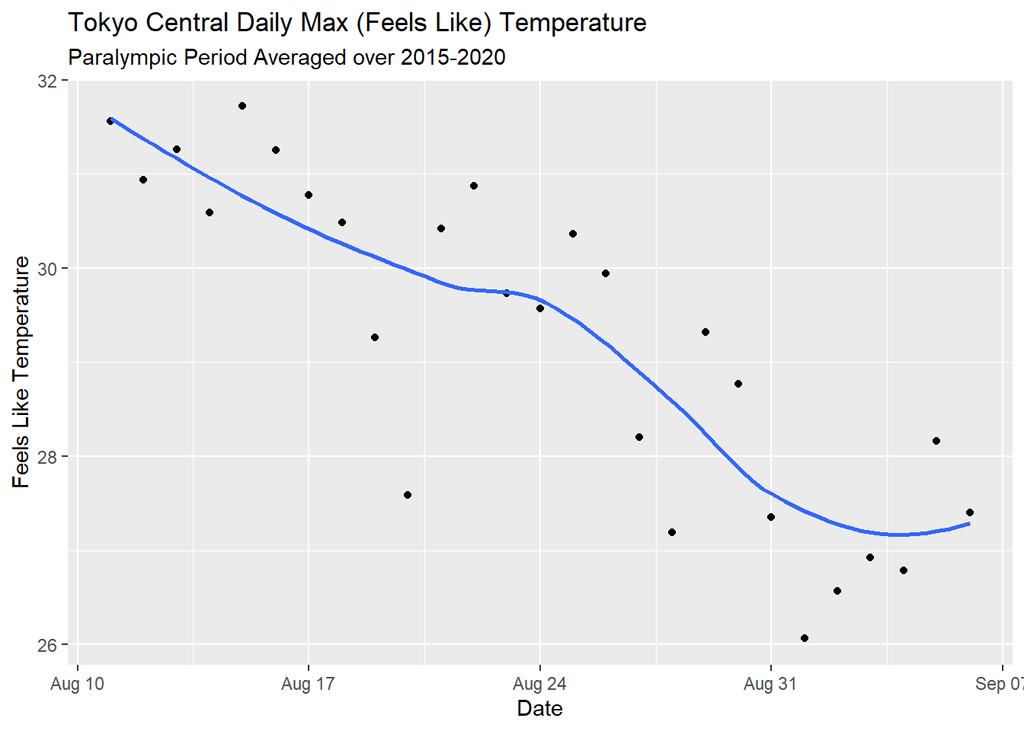

```r
gdf_p <- para_df %>%
  filter(venue == 'tokyo',
         hour(datetime) != 0) %>%
  mutate(feelsLike = as_vector(map2(temperature, humidity, heatIndex))) %>%
  group_by(day(datetime)) %>%
  summarise(`Feels Like Temperature` = mean(feelsLike, na.rm = TRUE),
           Date = max(date(datetime))) %>%
  rename('Day' = `day(datetime)`)

ggplot(data = gdf_p, aes(x = Date, y = `Feels Like Temperature`)) +
  geom_point() +
  geom_smooth(se = FALSE) +
  ggtitle('Tokyo Central Daily Max (Feels Like) Temperature',
          subtitle = 'Paralympic Period Averaged over 2015-2020')
```